# Practical Machine Learning

Enna Martinez

5/11/2020

## Background

Using devices such as Jawbone Up, Nike FuelBand, and Fitbit it is now possible to collect a large amount of data about personal activity relatively inexpensively. These type of devices are part of the quantified self movement – a group of enthusiasts who take measurements about themselves regularly to improve their health, to find patterns in their behavior, or because they are tech geeks. One thing that people regularly do is quantify how much of a particular activity they do, but they rarely quantify how well they do it.

The goal of this analysis is to predict the manner in which 6 participants did an exercise based on the data from accelerometers on the belt, forearm, arm, and dumbell. They were asked to perform barbell lifts correctly and incorrectly in 5 different ways.

## Data processing

The data used for this project come from Human Activity Recognition (HAR). HAR has emerged as a key research area in the last years and is gaining increasing attention by the pervasive computing research community, especially for the development of context-aware systems. There are many potential applications for HAR, like: elderly monitoring, life log systems for monitoring energy expenditure and for supporting weight-loss programs, and digital assistants for weight lifting exercises.

The fisrt step is download the training and testing databases from the website.

```r
library(caret)
library(randomForest)
train<-read.csv("pml-training.csv",row.names=1,na.strings = "")
test<-read.csv("pml-testing.csv",row.names=1,na.strings = "NA")
```

Since the analysis is trying to predict the manner in which the participant will do the excercise, we need to get rid of the variables that have near zero variance in both data sets. Also, all columns with missing values should be removed to avoid issues and noise within our prediction model.

```r
# Remove variables with near zero variance
nearZ<-nearZeroVar(train,saveMetrics=TRUE)
train<-train[,!nearZ$nzv]
test<-test[,!nearZ$nzv]

# Remove variables NA
train<-train[,(colSums(is.na(train)) == 0)]
test<-test[,(colSums(is.na(test)) == 0)]

# Remove unnecessary columns
cols_rm<-c("user_name","raw_timestamp_part_1","raw_timestamp_part_2","cvtd_timestamp","num_window")

train<-train[,!(names(train) %in% cols_rm)]
test<-test[,!(names(test) %in% c(cols_rm,"problem_id"))]

train$classe<-as.factor(train$classe)
```

Once the data has been cleanse we need to separate the training data between training and validation sets.

```r
inTrain<-createDataPartition(y=train$classe, p=0.7, list=FALSE)
training<-train[inTrain,]
validation<-train[-inTrain,]
```

## Random Forest

Due to the type of data, we will try to use a random forest to predict our model.

```r
set.seed(1234)

# Fit random forest model
modFit<-randomForest(classe~.,data=training)
val_pred<-predict(modFit, newdata=validation)
```

Once we have the model, it is necessary to perform some tests.

```r
# Check model performance
confusionMatrix(val_pred,validation$classe)
```

```
## Confusion Matrix and Statistics
##
##           Reference
## Prediction    A    B    C    D    E
##          A 1673    5    0    0    0
##          B    0 1128    2    0    0
##          C    0    6 1022   13    2
##          D    0    0    2  950    4
##          E    1    0    0    1 1076
##
## Overall Statistics
##
##                Accuracy : 0.9939
##                  95% CI : (0.9915, 0.9957)
##     No Information Rate : 0.2845
##     P-Value [Acc > NIR] : < 2.2e-16
##
##                   Kappa : 0.9923
##
##  Mcnemar's Test P-Value : NA
##
## Statistics by Class:
##
##                      Class: A Class: B Class: C Class: D Class: E
## Sensitivity            0.9994   0.9903   0.9961   0.9855   0.9945
## Specificity            0.9988   0.9996   0.9957   0.9988   0.9996
## Pos Pred Value         0.9970   0.9982   0.9799   0.9937   0.9981
## Neg Pred Value         0.9998   0.9977   0.9992   0.9972   0.9988
## Prevalence             0.2845   0.1935   0.1743   0.1638   0.1839
## Detection Rate         0.2843   0.1917   0.1737   0.1614   0.1828
## Detection Prevalence   0.2851   0.1920   0.1772   0.1624   0.1832
## Balanced Accuracy      0.9991   0.9950   0.9959   0.9921   0.9970
```

```r
# Check important variable
importance(modFit)
```

```
##                      MeanDecreaseGini
## roll_belt                   884.77320
## pitch_belt                  483.30679
## yaw_belt                    617.11746
## total_accel_belt            161.21725
## gyros_belt_x                 72.66491
## gyros_belt_y                 79.42437
## gyros_belt_z                229.37919
## accel_belt_x                 81.92451
## accel_belt_y                 82.84545
## accel_belt_z                266.51662
## magnet_belt_x               171.93998
## magnet_belt_y               274.19032
## magnet_belt_z               281.50375
## roll_arm                    226.93234
## pitch_arm                   119.39009
## yaw_arm                     176.92994
## total_accel_arm              70.18148
## gyros_arm_x                  93.88195
## gyros_arm_y                  89.76969
## gyros_arm_z                  41.36024
## accel_arm_x                 164.42732
## accel_arm_y                 106.97371
## accel_arm_z                  94.00583
## magnet_arm_x                183.82554
## magnet_arm_y                159.52407
## magnet_arm_z                130.95819
## roll_dumbbell               294.70952
## pitch_dumbbell              125.72199
## yaw_dumbbell                186.20704
## total_accel_dumbbell        177.57722
## gyros_dumbbell_x             91.95941
## gyros_dumbbell_y            176.01208
## gyros_dumbbell_z             59.59504
## accel_dumbbell_x            183.65656
## accel_dumbbell_y            287.60585
## accel_dumbbell_z            225.22974
## magnet_dumbbell_x           342.40808
## magnet_dumbbell_y           456.83103
## magnet_dumbbell_z           515.48983
## roll_forearm                421.06292
## pitch_forearm               546.32140
## yaw_forearm                 124.34908
## total_accel_forearm          76.26855
## gyros_forearm_x              53.93051
## gyros_forearm_y              86.43019
## gyros_forearm_z              57.36420
## accel_forearm_x             240.65877
## accel_forearm_y             101.02330
## accel_forearm_z             167.82617
## magnet_forearm_x            159.92278
## magnet_forearm_y            163.26798
## magnet_forearm_z            193.90509
```

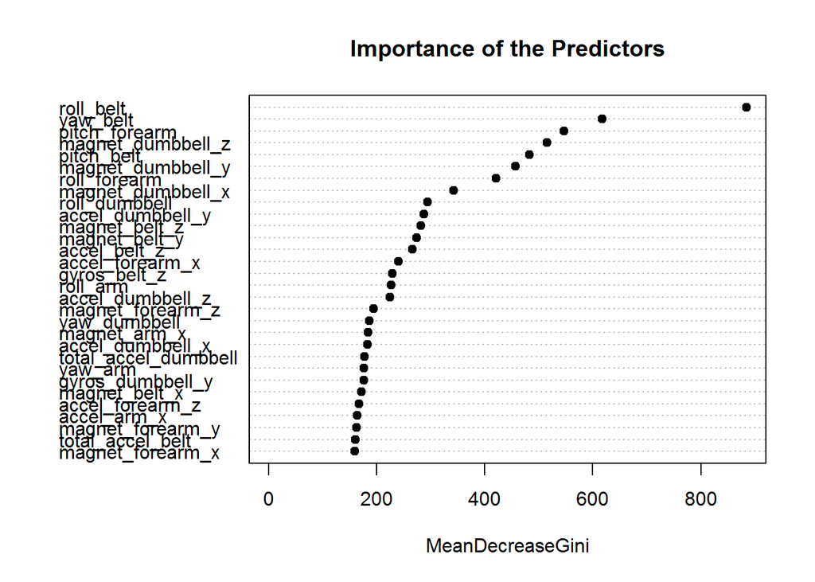

```r
varImpPlot(modFit, pch=19,col=1,cex=1,main = "Importance of the Predictors")
```

## Results

The last step is to use the model to predict on the testing set.

```r
test_pred <- predict(modFit, newdata=test)
write_results <- function(x) {
        n <- length(x)
        for (i in 1:n) {
                filename <- paste0("problem_id", i, ".txt")
                write.table(x[i], file=filename, quote=FALSE, row.names=FALSE,col.names=FALSE)
        }
}
write_results(test_pred)
```